# Exercício 11

Neiton Carvalho da Silva

11/07/2020

## Exercício 11 - Gráfico

UFRPE - Universidade Federal Rural de Pernambuco  
Disciplina: Computação para Análise de Dados  
Profº Ermeson Andrade

### Questão 01

Questão 1) (20 pontos) Use os dados abaixo para gerar os gráfico. Para o segundo gráfico (barras), use a escala logarítmica e as seguintes cores: “#E6E6E6”, “#666666”. Além disso, os gráficos podem ser organizados com a função layout().  
Dados

```r
MRT_1F <-c(517.1468515630205, 85.13094142168089, 30.333207896694553, 12.694776264558937, 3.3041601673945418, 1.1823111717498882, 1.1892293502386786)
MRT_3F <-c(156.68929936163462, 11.540837783562276, 0.4512835621696538, 0.4509797929766453, 0.4502068233039181, 0.4496185276300172, 0.4543157082191288)
MRT_5F <-c(83.90319666471157, 0.3068151086494968, 0.30522314133037304, 0.3072588968084928, 0.30655265997285697, 0.3055812715727718, 0.3053297166713006)
MRT_10F <-c(29.55430642951759, 0.19832832665772515, 0.1971923924717474, 0.19796648905716516, 0.19615594370806338, 0.2034569237883263, 0.19617420889447737)
MRT_15F <-c(11.317736530583566, 0.167364215666193, 0.16172168266811013, 0.16701085329580515, 0.1598052657153692, 0.1645934043532696, 0.16216563797118075)
MRT_sem_F <-c(11.93430909937736, 0.6095414637034009, 0.6060645101029295, 0.612167181646899, 0.6146761002685637, 0.6096747087200697, 0.6125810476877268)
clock <- c(0.1, 0.5, 1, 1.5, 2, 2.5, 3)
```

Gráfico de Linha

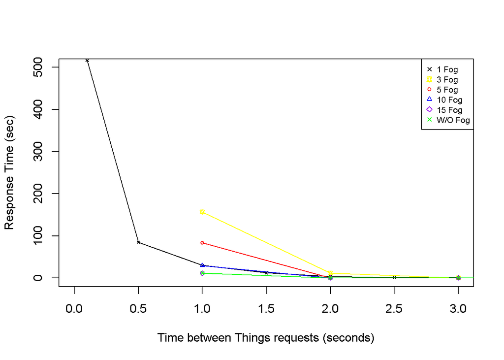

```r
#Gráfico de linha
plot(clock, MRT_1F, type="o", pch=4,
     cex=0.5, col="black",
     xlab="Time between Things requests (seconds)",
     ylab="Response Time (sec)",
#     main="Título do Gráfico",
     cex.lab=1, cex.axis=1,
#     cex.main=3, # Tamanho do Objeto
     xlim=c(0,3),
     ylim=c(0,500))
lines(MRT_3F, type = "o", cex = 0.6 , col = "yellow", pch=11)
lines(MRT_5F, type = "o", cex = 0.6 , col = "red", pch=1)
lines(MRT_10F, type = "o", cex = 0.6 , col = "blue", pch=2)
lines(MRT_15F, type = "o", cex = 0.6 , col = "purple", pch=5)
lines(MRT_sem_F, type = "o", cex = 0.6 , col = "green", pch=4)
legend("topright", pch = c(4,11,1,2,5,4),
       col =c("black","yellow","red","blue","purple","green"),
       legend = c("1 Fog", "3 Fog", "5 Fog", "10 Fog", "15 Fog", "W/O Fog"),
       cex = 0.7)
```

gráfico (barras)

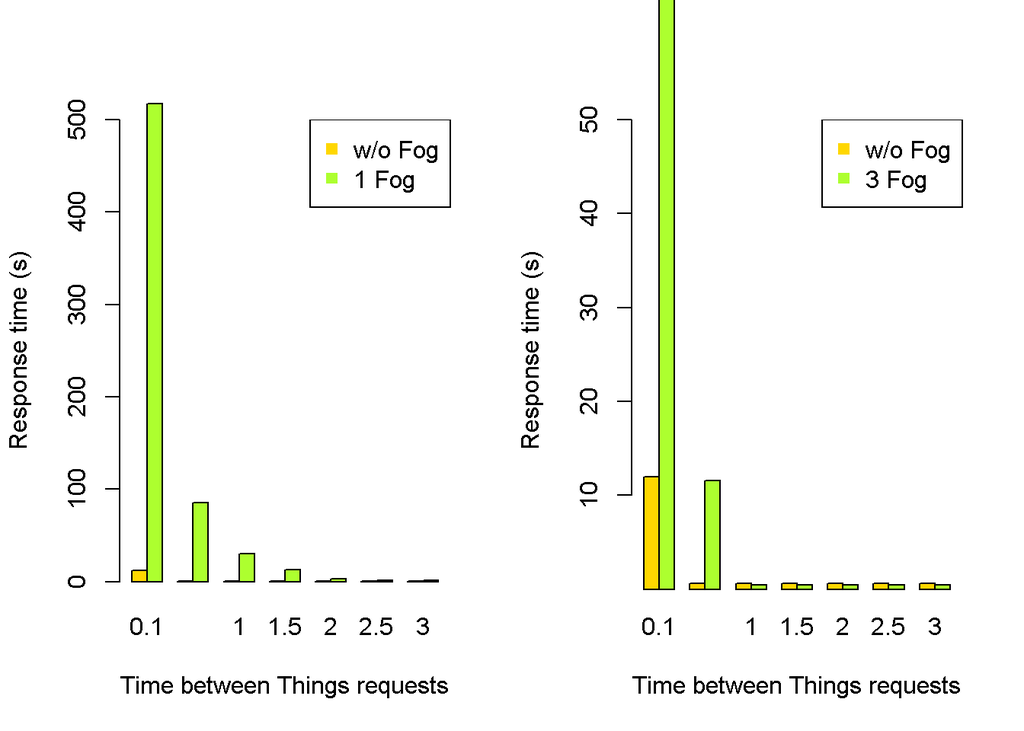

```r
##Gráfico de Barras

par(mfrow=c(1,2))
#01

barplot(matrix(c(MRT_sem_F, MRT_1F), 2,7, byrow = T),
        beside = T, col=c("#FFD700", "#ADFF2F"),
        ylab = "Response time (s)",
        xlab = "Time between Things requests",
        names.arg = c("0.1", "0.5","1","1.5","2","2.5","3"),
        ylim = c(0,500))
#axis(side = 2, at = c(seq(2,500,2)))
legend("topright", pch = c(15,15,15), legend = c("w/o Fog", "1 Fog"), col = c("#FFD700", "#ADFF2F"))

#02
barplot(matrix(c(MRT_sem_F, MRT_3F), 2,7, byrow = T),
        beside = T, col=c("#FFD700", "#ADFF2F"),
        ylab = "Response time (s)",
        xlab = "Time between Things requests",
        names.arg = c("0.1", "0.5","1","1.5","2","2.5","3"),
        ylim = c(0.8,50))
legend("topright", pch = c(15,15,15), legend = c("w/o Fog", "3 Fog"), col = c("#FFD700", "#ADFF2F"))
```

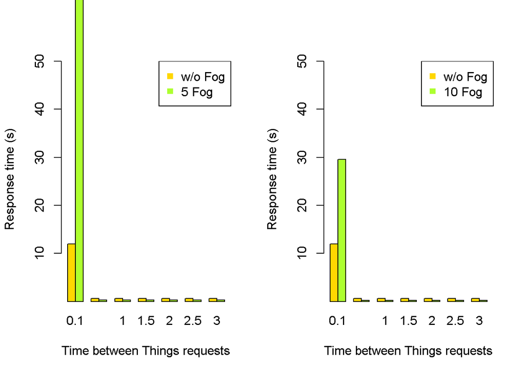

```r
#03
barplot(matrix(c(MRT_sem_F, MRT_5F), 2,7, byrow = T),
        beside = T, col=c("#FFD700", "#ADFF2F"),
        ylab = "Response time (s)",
        xlab = "Time between Things requests",
        names.arg = c("0.1", "0.5","1","1.5","2","2.5","3"),
        ylim = c(0.8,50))
legend("topright", pch = c(15,15,15), legend = c("w/o Fog", "5 Fog"), col = c("#FFD700", "#ADFF2F"))

#04
barplot(matrix(c(MRT_sem_F, MRT_10F), 2,7, byrow = T),
        beside = T, col=c("#FFD700", "#ADFF2F"),
        ylab = "Response time (s)",
        xlab = "Time between Things requests",
        names.arg = c("0.1", "0.5","1","1.5","2","2.5","3"),
        ylim = c(0.8,50))
legend("topright", pch = c(15,15,15), legend = c("w/o Fog", "10 Fog"), col = c("#FFD700", "#ADFF2F"))
```

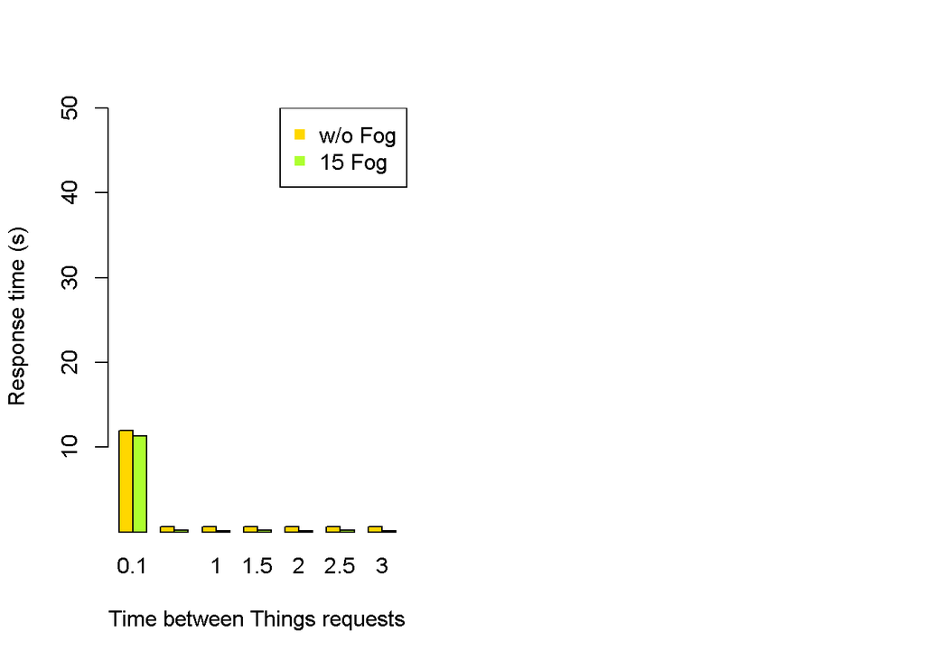

```r
#05
barplot(matrix(c(MRT_sem_F, MRT_15F), 2,7, byrow = T),
        beside = T, col=c("#FFD700", "#ADFF2F"),
        ylab = "Response time (s)",
        xlab = "Time between Things requests",
        names.arg = c("0.1", "0.5","1","1.5","2","2.5","3"),
        ylim = c(0.8,50))
legend("topright", pch = c(15,15,15), legend = c("w/o Fog", "15 Fog"), col = c("#FFD700", "#ADFF2F"))
```

### Questão 02

Questão 2) (10 pontos) Para a tabela abaixo que classifica a qualidade de refeição de acordo com categorias de preços crie um gráfico de barras empilhadas.

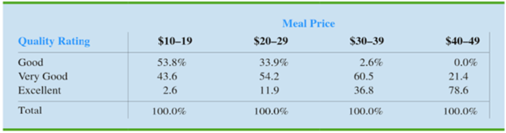

tabela

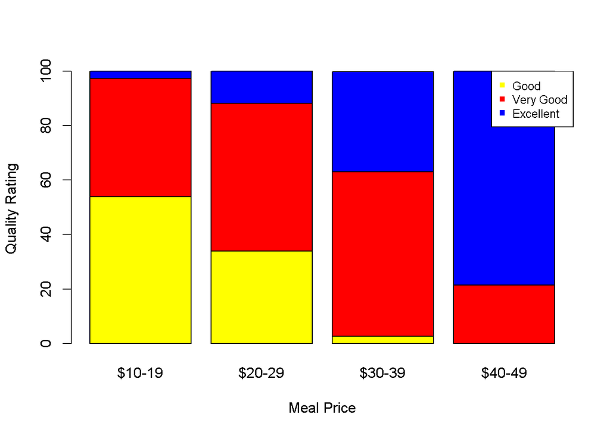

```r
# 2 questão :
good<-c("53.8", "33.9", "2.6","0.0")
very<-c("43.6", "54.2", "60.5", "21.4")
excellent<-c("2.6", "11.9", "36.8", "78.6")

barplot(matrix(c(good,very,excellent),3,4, byrow = T), col=c("yellow", "red", "blue"),
        names.arg = c("$10-19", "$20-29", "$30-39", "$40-49"),
        ylab = "Quality Rating",
        xlab = "Meal Price")
legend("topright", pch = c(15,15,15), legend = c("Good", "Very Good", "Excellent"),
       col = c("yellow", "red", "blue"), cex = 0.8)
```

### Questão 03

Questão 03) (10 pontos) Faça o histograma das temperaturas do mês de maio do dataset airquality. No entanto, primeiro converta as temperaturas para graus Celsius através da expressão °C = (°F − 32) / 1.8. Após isso, gere o histograma. Também adicione título, nomes de eixos, cor e curva de densidade.  
Formula da conversão em Latex:  
$^{\circ}C=\frac{^{\circ}F - 32}{1,8}$

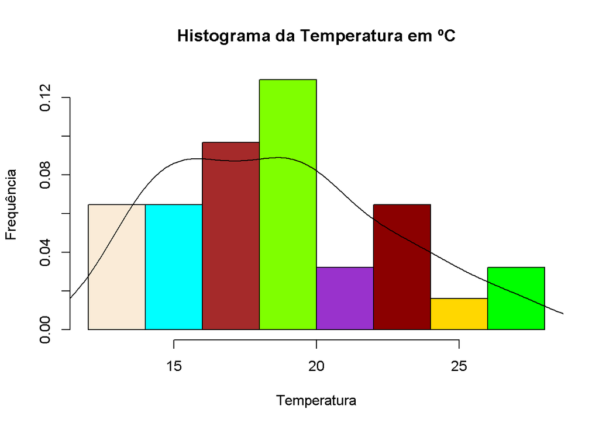

```r
# 3 questão:
library(dplyr)
b <- airquality %>%
        filter(Month == 5) %>%
        select(Temp) %>%
        mutate(celsius = (Temp-32)/1.8)

#b<-airquality$Temp[airquality$Month == 5]
#b<-(b-32)/1.8
hist(b$celsius, probability = T,
     col = c("#FAEBD7","#00FFFF","#A52A2A","#7FFF00","#9932CC", "#8B0000", "#FFD700","green"),
     xlab = "Temperatura",
     ylab = "Frequência",
     main = "Histograma da Temperatura em ºC")
db <- density(b$celsius)
lines(db)
```

### Questão 04

Questão 04) (10 pontos) Crie um gráfico de pizza com a porcentagem da tabela total de vendas por país. Use o dataset abaixo. Inclua a porcentagem de cada fatia, as cores das fatias e o nome do gráfico. Adicionalmente, use o comando legend() para incluir a legenda do gráfico.  
a) sales <- read.table(“https://training-course-material.com/images/8/8f/Sales.txt”,header=TRUE)

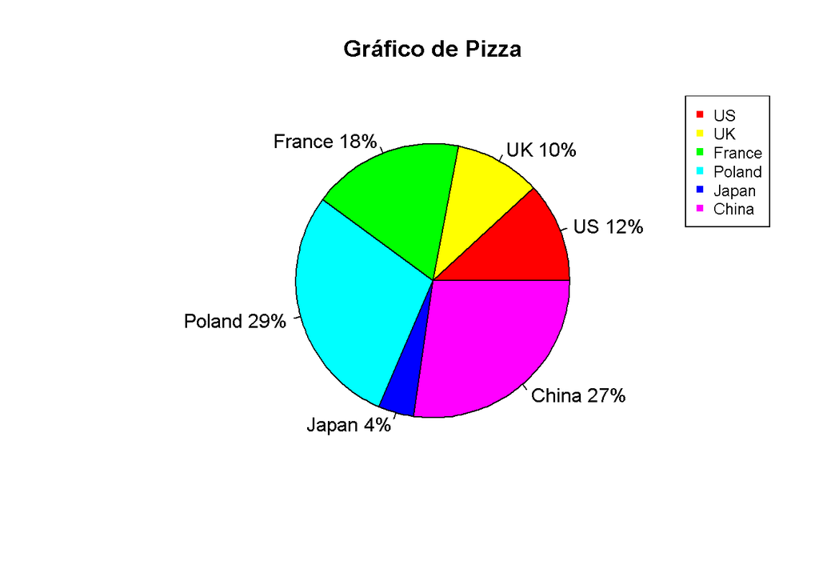

```r
sales <- read.table("https://training-course-material.com/images/8/8f/Sales.txt",header=TRUE)
pct <- round(sales$SALES/sum(sales$SALES)*100)
lbls <- paste(sales$COUNTRY, pct)
lbls <- paste(lbls,"%",sep="")
pie(sales$SALES,lbls,
    main = "Gráfico de Pizza",
    col = rainbow(6))
legend("topright", pch = c(15,15,15), legend = sales$COUNTRY,
       col = rainbow(6), cex = 0.8)
```

### Questão 05

Questão 05) (10 pontos) Utilize os dados de contagens de insetos em unidades experimentais agrícolas tratados com inseticidas diferentes disponível no R em InsectSprays e construa um boxplot sem a presença dos outliers para os 6 tipos de inseticidas. Coloque título e nomes de eixos adequados. Além disso, as caixas devem ser preenchidas com a cor “yellow”.

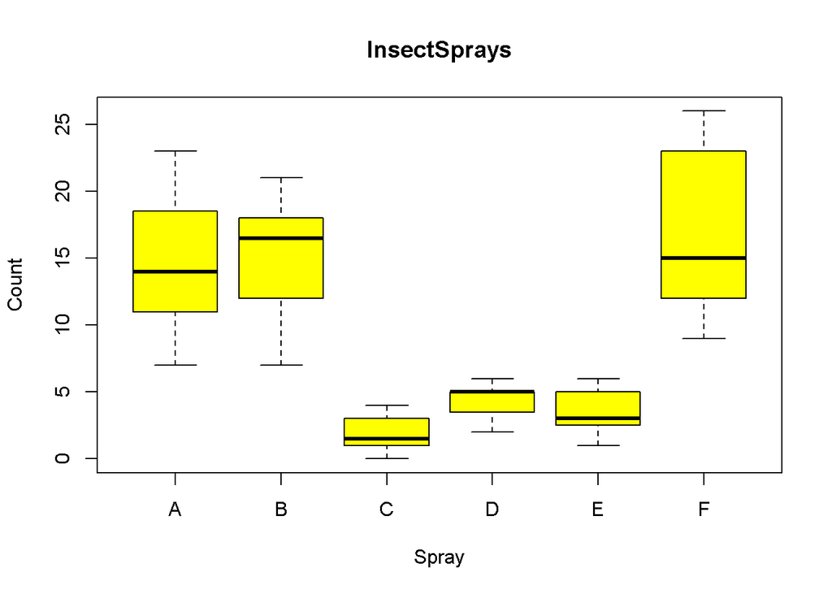

```r
boxplot(count ~ spray , data=InsectSprays,
        xlab = "Spray",
        ylab = "Count",
        main = "InsectSprays",
        col = c("yellow"),
        outline=FALSE)
```

### Questão 06

Questão 06) (10 pontos) Utilizando o dataset mtcars, faça um gráfico de dispersão do peso do carro (wt) em relação as milhas percorridas (mpg). Coloque título, legenda e nomes nos eixos. Também adicione a linha de tendência utilizando a função abline().

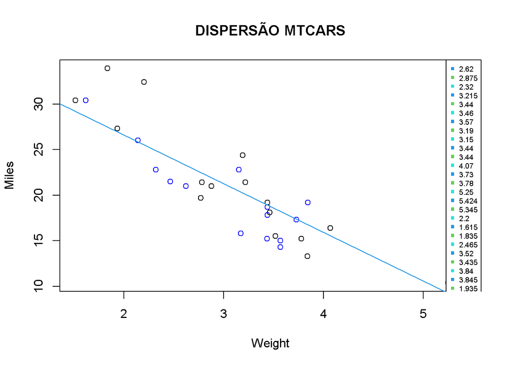

```r
plot(mtcars$wt, mtcars$mpg,
     main = "DISPERSÃO MTCARS",
     xlab = "Weight",
     ylab = "Miles",
     col = c("blue", "black"))
legend("topright", pch = c(15,15,15),
       legend = mtcars$wt,
       col = unique(mtcars$gear),
       cex = 0.6)
abline(
  lm(mtcars$mpg~mtcars$wt),
  col=unique(mtcars$gear))
```

### Questão 07

Questão 07) (3.0 pontos) Gere os gráficos abaixo a partir dos seguintes dados: monitoringCloudData_0.1.csv, monitoringCloudData_0.5.csv, monitoringCloudData_1.csv e monitoringCloudData_NONE.csv. Esse dados consistem de informações de monitoramento dos recursos de uma máquina virtual. Basicamente, é necessário gerar gráficos de linha do tempo de coleta dos recursos (currentTime) em relação a memória usada (usedMemory). Porém, é necessário ajustar a coluna “currentTime” para que o tempo fique contínuo e a coluna “usedMemory” para que todas as informações fiquem megabytes.Por fim, use a função layout() para organizar os gráficos.

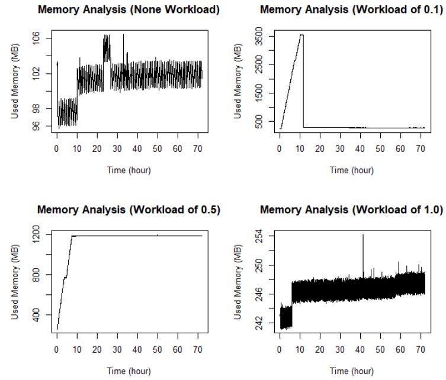

```r
setwd("C:/mestrado_UFRPE_Informatica_Aplicada_Neiton/Computacao_para_Analise_de_Dados/Atividades/Exercício 11")
getwd()
```

```
## [1] "C:/mestrado_UFRPE_Informatica_Aplicada_Neiton/Computacao_para_Analise_de_Dados/Atividades/Exercício 11"
```

[figure not shown]

```r
library(readr)
library(dplyr)
library(tidyr)
library(stringr)
library(tidyverse)
library(ggplot2)
library(lattice)

par(mfrow=c(1,2))
################################################################################
gera_grafico <- function(df,x){

  df <- df%>%
    separate(
      col="currentTime",
      into = c("data","tempo"),
      sep = 11
    )

  df <- df%>%
    separate(
      col="tempo",
      into = c("hora","milessegundo"),
      sep = 2
    )

  #transformando tudo em MB

  df <- df%>%
    separate(
      col="usedMemory",
      into = c("uso","byte"),
      sep = -2
    )

  df$uso <- as.double(df$uso)
  df$hora <- as.integer(df$hora)


  for (i in 1:nrow(df)){
    if (df[i,8] == "GB") {
      df[i,7] <- df[i,7] * 1024
    }else{
      df[i,7] <- df[i,7]
    }
  }

  #limpando tudo
  df <- df%>%select("hora","uso")

  #Escolhendo o título do gráfico
  if(x == 1 ){
    aux <- "Memory Analysis (None Workload)"
  }else if(x == 2){
    aux <- "Memory Analysis (Workload of 0.1)"
  }else if(x == 3){
    aux <- "Memory Analysis (Workload of 0.5)"
  }else{
    aux <- "Memory Analysis (Workload of 1.0)"
  }


  #Agora gerar o gráfico
  plot( sort(df$hora, decreasing = FALSE),df$uso,
        type = "l",
        xlab = "Time (hour)",
        ylab = "Used Memory(MB)",
        main = aux,
        ylim = c(min(df$uso),max(df$uso)),
        xlim = c(min(df$hora),max(df$hora))
  )

}

################################################################################

#Primeiro Gráfico --> monitoringCloudData_NONE.csv
df_none <- read.csv("monitoringCloudData_NONE.csv")
gera_grafico(df_none,1)

#Segundo Gráfico --> monitoringCloudData_1.csv
df_1 <- read.csv("monitoringCloudData_1.csv")
gera_grafico(df_1,2)
```

[figure not shown]

```r
#Terceiro Gráfico --> monitoringCloudData_0.5.csv
df_05 <- read.csv("monitoringCloudData_0.5.csv")
gera_grafico(df_05,3)

#Quarto Gráfico --> monitoringCloudData_0.1.csv
df_01 <- read.csv("monitoringCloudData_0.1.csv")
gera_grafico(df_01,4)
```